We explore the partitioning of Mankiw, Romer and Weil’s dataset in “A Contribution to the Empirics of Economic Growth” through the use of dimensionality reduction/clustering algorithms and discover a few puzzles along the way. The paper’s results seem to be robust to different partitioning methods, as the authors suggest, although we don’t test this rigorously. Results for the Augmented Solow Model are also covered although aren’t displayed here and can be viewed using the original Rmarkdown scripts on [GitHub](https://github.com/edgOnGithub/edgOnGithub.github.io/tree/master/_posts).

## Exploring Subsets

MRW estimate the Solow and Augmented Solow model on three different subsets of the data. They use a ‘Non-Oil’ group of countries; an ‘Intermediate’ group and an ‘OECD’ group. However, group membership isn’t mutually exclusive which makes visualisation a little tricky as we’ll see in a bit. Furthermore, there are 23 observations that don’t match any of these criteria in the dataset which is a little bizarre - the authors don’t really have observations to spare when starting at 121.

```r
library(dplyr)
left_out_obs <- MRW_clean %>%
  filter(N == 0) %>%
  filter(O == 0) %>%
  filter(I == 0)

left_out_obs %>%
  head %>%
  knitr::kable()
```

| number | country | N | I | O | 1960 | 1985 | gdp_ch | working_age_pop_ch | s | school | n_g_d |
| --- | --- | --- | --- | --- | --- | --- | --- | --- | --- | --- | --- |
| 91 | Barbados | 0 | 0 | 0 | 3165 | NA | 4.8 | NA | 0.195 | 12.1 | NA |
| 111 | Guyana | 0 | 0 | 0 | 2761 | NA | 1.1 | NA | 0.324 | 11.7 | NA |
| 114 | Surinam | 0 | 0 | 0 | 3226 | NA | 4.5 | NA | 0.194 | 8.1 | NA |
| 118 | Fiji | 0 | 0 | 0 | 3634 | NA | 4.2 | NA | 0.206 | 8.1 | NA |
| 13 | Gabon | 0 | 0 | 0 | 1307 | 5350 | 7.0 | 1.4 | 0.221 | 2.6 | 0.064 |
| 14 | Gambia, The | 0 | 0 | 0 | 799 | NA | 3.6 | NA | 0.181 | 1.5 | NA |

Whilst a lot of these observations are missing values, nine of them have enough data to be included in the model and an almost 10% increase in sample size, even from a more heterogeneous group such as these, would probably improve the power of their tests.

Moving on from these excluded observations we now turn to whether the partitioning, or at least the semi/sort-of partitioning, is justified in the data.

## Clustering

```r
library(plotly)

plot_ly(MRW_clean,
        type = 'scatter3d',
        mode = 'markers',
        x = ~jitter(O),
        y = ~jitter(I),
        z= ~jitter(N),
        color = ~`1985`,
        text = ~paste0(country,
                       '<br>OECD: ',
                       as.logical(O),
                       '<br>Intermediate: ',
                       as.logical(I),
                       '<br>Non-Oil: ',
                       as.logical(N)),
        hoverinfo = 'text') %>%
    layout(scene = list(xaxis = list(title = 'OECD'),
                     yaxis = list(title = 'Intermediate'),
                     zaxis = list(title = 'Non-Oil')))
```

[interactive chart not shown]

It makes sense to me to replace MRW’s original dummy structure with these new, mutually exclusive dummies. Instinctively, using non-mutually exclusive dummies to partition the dataset with which to run the regressions seems wrong to me - we’re oversampling some datapoints in my opinion.[^1]

Here we encode the four new dummies and convert them from separate dummy columns into a single column of factors named `club`. The conversion is a little finnicky and requires converting the dummy columns to a matrix and post multiplying by a column of 1s to get a single factor column:

```r
club_dummies <- MRW_clean %>%
  transmute(developing_no_oil = ifelse(((O == 0) & (N == 1) & (I == 0)), 1, 0),
         rich = ifelse(((O == 1) & (N == 1) & (I ==1)), 1, 0),
         intermediate_no_oil = ifelse(((O == 0) & (N == 1) & (I == 1)), 1, 0),
         oil = ifelse(((N == 0) & (I == 0) & (O == 0)), 1, 0))

clubs <- factor(club_dummies %>% as.matrix() %*% 1:ncol(club_dummies), labels = colnames(club_dummies))
MRW_clean$club <- clubs
```

Now we can perform the clustering analysis - the above steps weren’t strictly necessary but the distinct factors let us visualise different groups with colour mappings easier.

Here we perform [t-SNE](https://lvdmaaten.github.io/tsne/) which seems to be all the rage in the clustering scene right now. First, we create a function to perform the clustering and return a tibble with both the clustered co-ordinates and the corresponding features:

```r
library(Rtsne)
library(ggplot2)
library(purrr)

generate.tsne <- function(perplexity, data, dims = 2){
  data <- data %>%
    na.omit

  tsne_data <- Rtsne(X = data %>% select(-club,
                                         -country,
                                         -number),
                     perplexity = perplexity,
                     dims = dims,
                     verbose = FALSE,
                     max_iter = 500)
  tsne_df <- tibble(x = tsne_data$Y[,1],
                    y = tsne_data$Y[,2])
  if (dims == 3){
    tsne_df$z <- tsne_data$Y[,3]
  }

  tsne_df <- bind_cols(tsne_df,
                       data)
  tsne_df$perplexity <- perplexity
  return(tsne_df)

}
```

Next, we plot the results in two dimensions and use the new factor we created as a colour mapping:

[interactive chart not shown]

```r
tsne_df <- generate.tsne(30, MRW_clean)
p <- ggplot(tsne_df,
       aes(x = x,
           y = y,
           text = country)) +
  geom_point(aes(size = `1985`,
                 color = club)) +
  guides(size = 'none') +
  theme_minimal() +
  ggtitle('Clustering/Dimensionality Reduction Using t-SNE with Colour')

q <- ggplot(tsne_df,
       aes(x = x,
           y = y,
           text = country)) +
  geom_point() +
  guides(size = 'none') +
  theme_minimal() +
  ggtitle('Clustering/Dimensionality Reduction Using t-SNE without Colour')
p <- ggplotly(p, tooltip = 'text')
q <- ggplotly(q, tooltip = 'text')

subplot(p, q) %>%
  layout(title = 'Clustering with and without group colours')
```

Whilst the plot on the left makes a reasonable argument for partitioning the dataset I’d argue that a lot of this comes from the aesthetics `size` and `colour` we’ve supplied `ggplot`. Therefore, on the right is the same plot stripped of this additional information.

[interactive chart not shown]

```r
many_tsne <- 1:30 %>%
  map_df(generate.tsne, data = MRW_clean)

## plotly
ax <- list(
  title = '',
  zeroline = FALSE,
  showline = FALSE,
  showticklabels = FALSE,
  showgrid = FALSE,
  range = c(-50, 50)
)
plot_ly(many_tsne,
        x = ~x,
        y = ~y,
        color = ~club,
        frame = ~perplexity,
        type = 'scatter',
        mode = 'markers',
        text = ~country,
        hoverinfo = 'text',
        marker = list(size = 15)) %>%
    animation_opts(
    1000, easing = "elastic", redraw = FALSE
  ) %>%
  animation_button(
    x = 0, xanchor = "left", y = 0.1, yanchor = "top"
  ) %>%
  animation_slider(
    currentvalue = list(prefix = "Perplexity: ", font = list(color="red",
                                                             size = 25))
  ) %>%
  layout(xaxis = ax, yaxis = ax, title = 't-SNE Clustering as a Function of Perplexity')
```

I think the following is a pretty good illustration of simplicity’s importance in communicating ideas graphically:

```r
many_tsne_3d <- 1:30 %>%
  map_df(generate.tsne, data = MRW_clean, dims = 3)
plot_ly(many_tsne_3d,
        x = ~x,
        y = ~y,
        z= ~z,
        color = ~club,
        frame = ~perplexity,
        type = 'scatter3d',
        mode = 'markers',
        text = ~country,
        hoverinfo = 'text',
        marker = list(size = 15)) %>%
  layout(title = 't-SNE Clustering as a Function of Perplexity in 3D')
```

[interactive chart not shown]

Another common dimensionality reduction or clustering approach is to use principal component analysis. Below we plot PCA using ggfortify’s addition to `autoplot`:

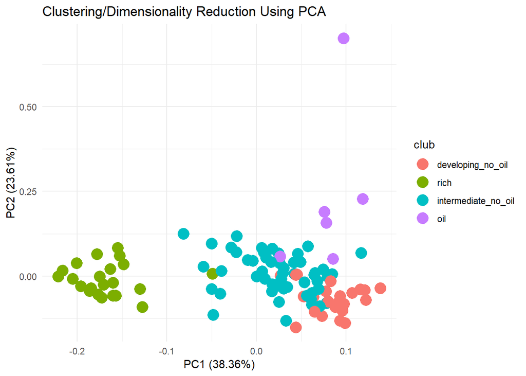

```r
library(ggfortify)
pca_df  <- prcomp(MRW_clean %>% na.omit %>% select(-number, -country, -club),
                 center = TRUE,
                 scale. = TRUE)

p <- autoplot(prcomp(MRW_clean %>% na.omit %>% select(-number, -country, -club),
                center= TRUE,
                scale. = TRUE),
         data = MRW_clean %>% na.omit %>% mutate(GDP = `1985`), colour = 'club', size = 5) +
  guides(size = 'none') +
  theme_minimal() +
  ggtitle('Clustering/Dimensionality Reduction Using PCA')

p
```

Mankiw, Romer and Weil decide to partition the dataset using their own domain knowledge and theory. This is an entirely valid way to make decisions and ideally, but not necessarily, the data would support their decision. I think in this case whilst the evidence using both PCA and t-SNE isn’t clear cut it can definitely be argued either way.

## New Dummy Model

Now we move on and compare our new dummy results with the originals.

Loading the original results and running the ‘new models’:

```r
library(readr)
solow_MRW <- read_csv('assets/Transformed Data/solow_MRW.csv')
augmented_MRW <- read_csv('assets/Transformed Data/augmented_MRW.csv')

solow_formula <- log(`1985`) ~ log(s) + log(`n_g_d`)

## Oil
oil_data <- MRW_clean %>%
  filter(club == 'oil') %>%
  filter(!is.na(school)) # MRW drop missing school observations to make comparisons easier

oil_model <- lm(solow_formula,
                data = oil_data)

## Intermediate
intermediate_data <- MRW_clean %>%
  filter(club == 'intermediate_no_oil') %>%
  filter(!is.na(school))

intermediate_model <- lm(solow_formula,
                         data = intermediate_data)

## Rich
rich_data <- MRW_clean %>%
  filter(club == 'rich') %>%
  filter(!is.na(school))

rich_model <- lm(solow_formula,
                 data = rich_data)

## Developing
developing_data <- MRW_clean %>%
  filter(club == 'developing_no_oil') %>%
  filter(!is.na(school))

developing_model <- lm(solow_formula,
                       data = developing_data)

#### Augmented Model
augmented_formula <- log(`1985`) ~ log(s) + log(n_g_d) + log(school)

##  Oil
aug_oil_model <- lm(augmented_formula,
                        data = oil_data)


## Intermediate
aug_intermediate_model <- lm(augmented_formula,
                             data = intermediate_data)


## OECD

aug_rich_model <- lm(augmented_formula,
                     data = rich_data)
## Developing
aug_developing_model <- lm(augmented_formula,
                           data = developing_data)
```

Here we collect and compare the results using functions from my very first post:

```r
library(knitr)
model_names <-  list('Oil',
                     'Intermediate',
                     'Rich',
                     'Developing')
solow_new_dummies <- collect.results(models = list(oil_model,
                                                   intermediate_model,
                                                   rich_model,
                                                   developing_model),
                                    names = model_names)

augmented_new_dummies <- collect.results(models = list(aug_oil_model,
                                                       aug_intermediate_model,
                                                       aug_rich_model,
                                                       aug_developing_model),
                                         names = model_names)

comparison_tbl <- bind_rows(solow_new_dummies %>%
                              select(term, estimate, subset) %>%
                              mutate(type = 'New'),
                            solow_MRW %>% select(term, estimate, subset) %>%
                              mutate(subset = paste0(subset, ' MRW'),
                                     type = 'Original'))
comparison_tbl %>%
  head %>%
  kable
```

| term | estimate | subset | type |
| --- | --- | --- | --- |
| (Intercept) | 26.9912257 | Oil | New |
| log(s) | 1.8019705 | Oil | New |
| log(n_g_d) | 5.9246642 | Oil | New |
| (Intercept) | 10.7498808 | Intermediate | New |
| log(s) | 1.0834370 | Intermediate | New |
| log(n_g_d) | 0.2858952 | Intermediate | New |

When we ignore the ‘Oil’ column the results are broadly similar although it’s worth noting that standard errors and confidence intervals aren’t displayed here:

```r
plot_new_vs_old <- function(term_type, data, std_error = FALSE ){
  if (std_error == TRUE){
    data <- data %>%
      mutate(estimate = `std.error`)
  }

  new_data <- data %>%
    filter(term == term_type) %>%
    filter(type == 'New') %>%
    mutate(estimate = abs(estimate))

  old_data <- data %>%
    filter(term == term_type) %>%
    filter(type == 'Original') %>%
    mutate(estimate =  abs(estimate))


  p <- plot_ly(new_data,
               x = ~subset,
               y = ~estimate,
               type = 'bar',
               color = ~subset)

  q <- plot_ly(old_data,
               x = ~subset,
               y = ~estimate,
               type = 'bar',
               color = ~subset,
               colors = "Set1")

  pq <- subplot(p, q, nrows = 1, shareY = TRUE) %>%
    layout(yaxis = list(title = term_type))
  return(pq)
}

p <- plot_new_vs_old('(Intercept)', comparison_tbl)

q <- plot_new_vs_old('log(s)', comparison_tbl)

r <- plot_new_vs_old('log(n_g_d)', comparison_tbl)

subplot(p,q,r,nrows = 3, titleY = TRUE) %>%
  layout(showlegend = FALSE,
         title = 'Comparing estimates with new and old partitions')
```

[interactive chart not shown]

Whilst the sample size reduction does increase the standard errors the difference doesn’t look to be huge - it’s hard to say whether this will have a large effect on the conclusions drawn from the data from this graph alone.

```r
comparison_tbl_se <- bind_rows(solow_new_dummies %>%
                              select(term, std.error, subset) %>%
                              mutate(type = 'New'),
                            solow_MRW %>% select(term, std.error, subset) %>%
                              mutate(subset = paste0(subset, ' MRW'),
                                     type = 'Original'))

p <- plot_new_vs_old('(Intercept)', comparison_tbl_se, std_error = TRUE)

q <- plot_new_vs_old('log(s)', comparison_tbl_se, std_error = TRUE)

r <- plot_new_vs_old('log(n_g_d)', comparison_tbl_se, std_error = TRUE)

subplot(p,q,r,nrows = 3, titleY = TRUE) %>%
  layout(showlegend = FALSE,
         title = 'Comparing standard errors with new and old partitions')
```

[interactive chart not shown]

## Conclusion

We’ve explored some of the modelling assumptions of Mankiw, Romer and Weil’s “A Contribution to the Empirics of Economic Growth” and found that subsetting the data along different lines doesn’t seem to largely change any results although we don’t examine this rigorously.

There’s supportive evidence in the data for splitting up observations although both the PCA and t-SNE, I’d argue, are by no means definitive.

Re-partitioning the data into mutually exclusive subsets is, in my opinion, an improvement on the original method.The last few graphs clearly highlight MRW were most likely justified in excluding economies largely reliant on oil.

[^1]: I think this boils down to the question: What population parameter are the authors trying to uncover? If the aim is to identify the parameter for each group e.g. for policy reasons or because they’re of interest in their own right I don’t see a problem. However, if the aim is to empirically identify the Solow model and these subsets are just drawn from some population, global hyper-parameter I think MRW’s could be improved upon. Finally, regardless of the above, why not include the dummies and their interactions in a pooled model and at the very least include our nine excluded observations?